# Case Study 2: DDSAnalytics

Kristi Herman

03/11/2020

## Introduction

- The purpose of this analysis is to determine that factors that lead to employee attrition, predict employee turnover, and predict monthly income.

```r
# Import dependencies
library(tidyverse)
```

```r
library(dplyr)
library(ggplot2)
library(naniar)
library(class)
library(caret)
library(corrplot)
library(ggthemes)
library(ggpubr)
library(gplots)
library(arsenal)
library(mltools)
library(GGally)
library(e1071)
# Import employee data and prediction data
empl_df <-  read.csv("CaseStudy2-data.csv")
```

- Basic Data Exploration

```r
# Check to make sure data imported
dim(empl_df)
```

```
## [1] 870  36
```

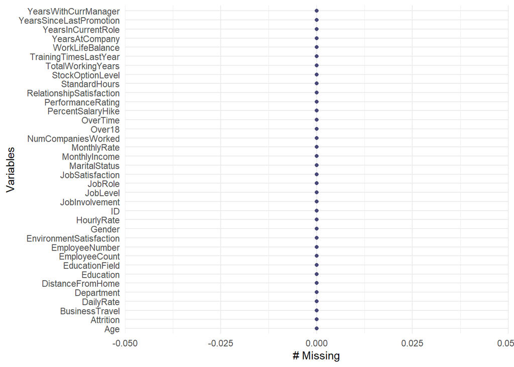

```r
View(empl_df)

# Check to see if there's any missing data
gg_miss_var(empl_df)
```

```r
# Get summary statistics
summary(empl_df)
```

```
##        ID             Age        Attrition           BusinessTravel
##  Min.   :  1.0   Min.   :18.00   No :730   Non-Travel       : 94
##  1st Qu.:218.2   1st Qu.:30.00   Yes:140   Travel_Frequently:158
##  Median :435.5   Median :35.00             Travel_Rarely    :618
##  Mean   :435.5   Mean   :36.83
##  3rd Qu.:652.8   3rd Qu.:43.00
##  Max.   :870.0   Max.   :60.00
##
##    DailyRate                       Department  DistanceFromHome   Education
##  Min.   : 103.0   Human Resources       : 35   Min.   : 1.000   Min.   :1.000
##  1st Qu.: 472.5   Research & Development:562   1st Qu.: 2.000   1st Qu.:2.000
##  Median : 817.5   Sales                 :273   Median : 7.000   Median :3.000
##  Mean   : 815.2                                Mean   : 9.339   Mean   :2.901
##  3rd Qu.:1165.8                                3rd Qu.:14.000   3rd Qu.:4.000
##  Max.   :1499.0                                Max.   :29.000   Max.   :5.000
##
##           EducationField EmployeeCount EmployeeNumber   EnvironmentSatisfaction
##  Human Resources : 15    Min.   :1     Min.   :   1.0   Min.   :1.000
##  Life Sciences   :358    1st Qu.:1     1st Qu.: 477.2   1st Qu.:2.000
##  Marketing       :100    Median :1     Median :1039.0   Median :3.000
##  Medical         :270    Mean   :1     Mean   :1029.8   Mean   :2.701
##  Other           : 52    3rd Qu.:1     3rd Qu.:1561.5   3rd Qu.:4.000
##  Technical Degree: 75    Max.   :1     Max.   :2064.0   Max.   :4.000
##
##     Gender      HourlyRate     JobInvolvement     JobLevel
##  Female:354   Min.   : 30.00   Min.   :1.000   Min.   :1.000
##  Male  :516   1st Qu.: 48.00   1st Qu.:2.000   1st Qu.:1.000
##               Median : 66.00   Median :3.000   Median :2.000
##               Mean   : 65.61   Mean   :2.723   Mean   :2.039
##               3rd Qu.: 83.00   3rd Qu.:3.000   3rd Qu.:3.000
##               Max.   :100.00   Max.   :4.000   Max.   :5.000
##
##                       JobRole    JobSatisfaction  MaritalStatus MonthlyIncome
##  Sales Executive          :200   Min.   :1.000   Divorced:191   Min.   : 1081
##  Research Scientist       :172   1st Qu.:2.000   Married :410   1st Qu.: 2840
##  Laboratory Technician    :153   Median :3.000   Single  :269   Median : 4946
##  Manufacturing Director   : 87   Mean   :2.709                  Mean   : 6390
##  Healthcare Representative: 76   3rd Qu.:4.000                  3rd Qu.: 8182
##  Sales Representative     : 53   Max.   :4.000                  Max.   :19999
##  (Other)                  :129
```

[output cut: 17 more lines]

```
##  Min.   : 0.00     Min.   :0.000         Min.   :1.000   Min.   : 0.000
##  1st Qu.: 6.00     1st Qu.:2.000         1st Qu.:2.000   1st Qu.: 3.000
##  Median :10.00     Median :3.000         Median :3.000   Median : 5.000
##  Mean   :11.05     Mean   :2.832         Mean   :2.782   Mean   : 6.962
##  3rd Qu.:15.00     3rd Qu.:3.000         3rd Qu.:3.000   3rd Qu.:10.000
##  Max.   :40.00     Max.   :6.000         Max.   :4.000   Max.   :40.000
##
##  YearsInCurrentRole YearsSinceLastPromotion YearsWithCurrManager
##  Min.   : 0.000     Min.   : 0.000          Min.   : 0.00
##  1st Qu.: 2.000     1st Qu.: 0.000          1st Qu.: 2.00
##  Median : 3.000     Median : 1.000          Median : 3.00
##  Mean   : 4.205     Mean   : 2.169          Mean   : 4.14
##  3rd Qu.: 7.000     3rd Qu.: 3.000          3rd Qu.: 7.00
##  Max.   :18.000     Max.   :15.000          Max.   :17.00
##
```

```r
str(empl_df)
```

```
## 'data.frame':    870 obs. of  36 variables:
##  $ ID                      : int  1 2 3 4 5 6 7 8 9 10 ...
##  $ Age                     : int  32 40 35 32 24 27 41 37 34 34 ...
##  $ Attrition               : Factor w/ 2 levels "No","Yes": 1 1 1 1 1 1 1 1 1 1 ...
##  $ BusinessTravel          : Factor w/ 3 levels "Non-Travel","Travel_Frequently",..: 3 3 2 3 2 2 3 3 3 2 ...
##  $ DailyRate               : int  117 1308 200 801 567 294 1283 309 1333 653 ...
##  $ Department              : Factor w/ 3 levels "Human Resources",..: 3 2 2 3 2 2 2 3 3 2 ...
##  $ DistanceFromHome        : int  13 14 18 1 2 10 5 10 10 10 ...
##  $ Education               : int  4 3 2 4 1 2 5 4 4 4 ...
##  $ EducationField          : Factor w/ 6 levels "Human Resources",..: 2 4 2 3 6 2 4 2 2 6 ...
##  $ EmployeeCount           : int  1 1 1 1 1 1 1 1 1 1 ...
##  $ EmployeeNumber          : int  859 1128 1412 2016 1646 733 1448 1105 1055 1597 ...
##  $ EnvironmentSatisfaction : int  2 3 3 3 1 4 2 4 3 4 ...
##  $ Gender                  : Factor w/ 2 levels "Female","Male": 2 2 2 1 1 2 2 1 1 2 ...
##  $ HourlyRate              : int  73 44 60 48 32 32 90 88 87 92 ...
```

[output cut: 22 more lines]

```r
# Confirm that these fields only have one value unique values, and min/max values are
unique(empl_df$Over18)
```

```
## [1] Y
## Levels: Y
```

```r
unique(empl_df$StandardHours)
```

```
## [1] 80
```

```r
unique(empl_df$EmployeeCount)
```

```
## [1] 1
```

```r
# Look at values in more fields
unique(empl_df$JobInvolvement)
```

```
## [1] 3 2 4 1
```

```r
str(unique(empl_df$EmployeeNumber))
```

```
##  int [1:870] 859 1128 1412 2016 1646 733 1448 1105 1055 1597 ...
```

- Data cleaning

```r
# Reorder columns
empl_data <- empl_df[c(1,11,3,2,4:10,12:36)]
head(empl_data)
```

```
##   ID EmployeeNumber Attrition Age    BusinessTravel DailyRate
## 1  1            859        No  32     Travel_Rarely       117
## 2  2           1128        No  40     Travel_Rarely      1308
## 3  3           1412        No  35 Travel_Frequently       200
## 4  4           2016        No  32     Travel_Rarely       801
## 5  5           1646        No  24 Travel_Frequently       567
## 6  6            733        No  27 Travel_Frequently       294
##               Department DistanceFromHome Education   EducationField
## 1                  Sales               13         4    Life Sciences
## 2 Research & Development               14         3          Medical
## 3 Research & Development               18         2    Life Sciences
## 4                  Sales                1         4        Marketing
## 5 Research & Development                2         1 Technical Degree
## 6 Research & Development               10         2    Life Sciences
##   EmployeeCount EnvironmentSatisfaction Gender HourlyRate JobInvolvement
```

[output cut: 41 more lines]

```r
str(empl_data)
```

```
## 'data.frame':    870 obs. of  36 variables:
##  $ ID                      : int  1 2 3 4 5 6 7 8 9 10 ...
##  $ EmployeeNumber          : int  859 1128 1412 2016 1646 733 1448 1105 1055 1597 ...
##  $ Attrition               : Factor w/ 2 levels "No","Yes": 1 1 1 1 1 1 1 1 1 1 ...
##  $ Age                     : int  32 40 35 32 24 27 41 37 34 34 ...
##  $ BusinessTravel          : Factor w/ 3 levels "Non-Travel","Travel_Frequently",..: 3 3 2 3 2 2 3 3 3 2 ...
##  $ DailyRate               : int  117 1308 200 801 567 294 1283 309 1333 653 ...
##  $ Department              : Factor w/ 3 levels "Human Resources",..: 3 2 2 3 2 2 2 3 3 2 ...
##  $ DistanceFromHome        : int  13 14 18 1 2 10 5 10 10 10 ...
##  $ Education               : int  4 3 2 4 1 2 5 4 4 4 ...
##  $ EducationField          : Factor w/ 6 levels "Human Resources",..: 2 4 2 3 6 2 4 2 2 6 ...
##  $ EmployeeCount           : int  1 1 1 1 1 1 1 1 1 1 ...
##  $ EnvironmentSatisfaction : int  2 3 3 3 1 4 2 4 3 4 ...
##  $ Gender                  : Factor w/ 2 levels "Female","Male": 2 2 2 1 1 2 2 1 1 2 ...
##  $ HourlyRate              : int  73 44 60 48 32 32 90 88 87 92 ...
```

[output cut: 22 more lines]

```r
dim(empl_data)
```

```
## [1] 870  36
```

```r
# Max and mins
min(empl_data[,36])
```

```
## [1] 0
```

```r
max(empl_data[,36])
```

```
## [1] 17
```

```r
# Drop Over18, StandardHours, EmployeeCount, ID, MonthlyRate
empl_data <- empl_data[ , -which(names(empl_data) %in% c("EmployeeNumber", "Over18","StandardHours", "EmployeeCount", "MonthlyRate", "HourlyRate", "DailyRate"))]

head(empl_data)
```

```
##   ID Attrition Age    BusinessTravel             Department DistanceFromHome
## 1  1        No  32     Travel_Rarely                  Sales               13
## 2  2        No  40     Travel_Rarely Research & Development               14
## 3  3        No  35 Travel_Frequently Research & Development               18
## 4  4        No  32     Travel_Rarely                  Sales                1
## 5  5        No  24 Travel_Frequently Research & Development                2
## 6  6        No  27 Travel_Frequently Research & Development               10
##   Education   EducationField EnvironmentSatisfaction Gender JobInvolvement
## 1         4    Life Sciences                       2   Male              3
## 2         3          Medical                       3   Male              2
## 3         2    Life Sciences                       3   Male              3
## 4         4        Marketing                       3 Female              3
## 5         1 Technical Degree                       1 Female              3
## 6         2    Life Sciences                       4   Male              3
##   JobLevel                JobRole JobSatisfaction MaritalStatus MonthlyIncome
```

[output cut: 34 more lines]

- Overall Attrition for the Dataset is 16%

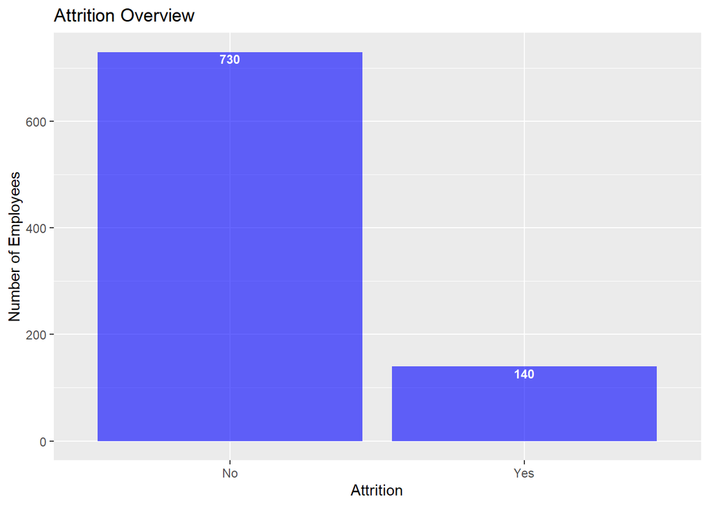

```r
# Determine and Plot Attrition for the Dataset
attr <- empl_data %>% group_by(Attrition) %>% summarize(count=n())
attr_pct <- attr$count[2]/dim(empl_data)[1]*100

p <- attr %>% ggplot(aes(x = Attrition, y = count)) +
  geom_bar(stat = "identity", fill = "blue", alpha = .6) +
  ggtitle("Attrition Overview") + xlab("Attrition") + ylab("Number of Employees") +
  geom_text(aes(y = count, label = count), fontface = "bold", vjust = 1.2, color = "white", size = 3)

p
```

- Average Monthly Salary By Job Role - Managers & Research Directors have the highest average monthly salaries

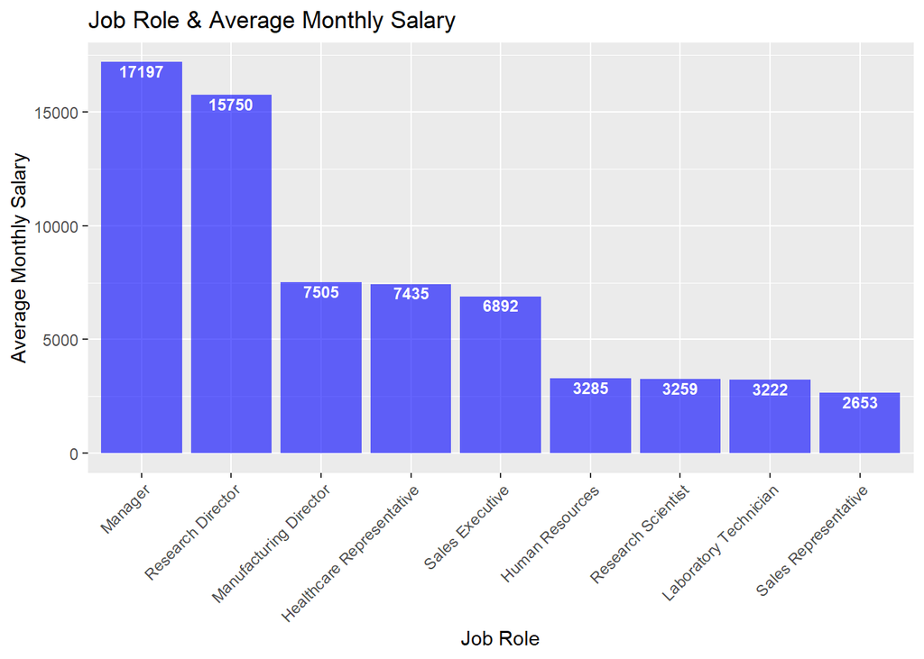

```r
#  Get average monthly salary for each job satisfaction categories
income <- empl_data %>% group_by(JobRole) %>% summarize(mean_size = round(mean(MonthlyIncome)), digits = 2)

# Plot data
p <- income %>%
  ggplot(aes(x = reorder(JobRole, -mean_size), y = mean_size)) +
  geom_bar(stat = "identity", fill = "blue", alpha = .6) +
  ggtitle("Job Role & Average Monthly Salary") + xlab("Job Role") + ylab("Average Monthly Salary") +
  geom_text(aes(y = mean_size, label = mean_size), fontface = "bold", vjust = 1.2, color = "white", size = 3)

p + rotate_x_text(45)
```

- Job Satisfaction By Job Role

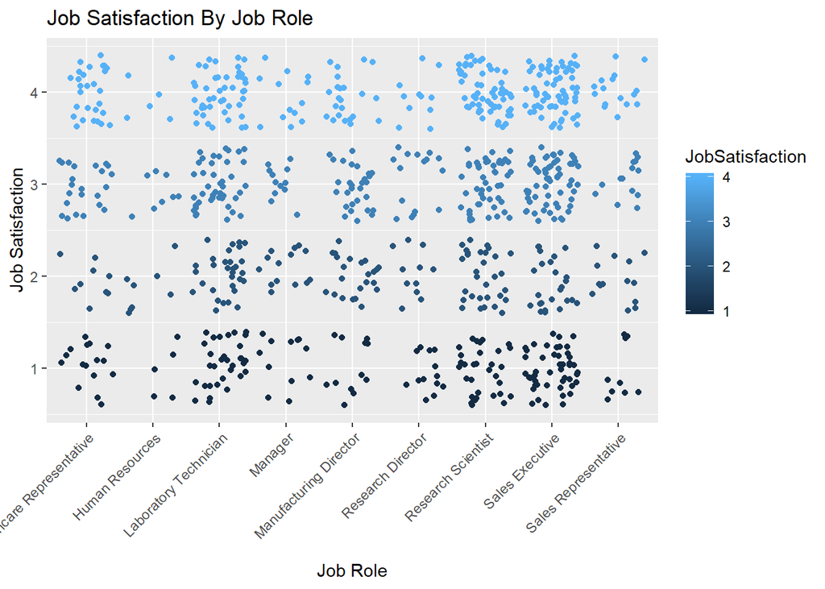

```r
#  Get average monthly salary for each job satisfaction categories
satis <- empl_data %>% group_by(JobRole)

# Distribution of job satisfaction by job role (Scatter)
p <- ggplot(data = empl_data) +
  geom_point(mapping = aes(x = JobRole, y = JobSatisfaction, color = JobSatisfaction), position ="jitter") +
  ggtitle("Job Satisfaction By Job Role") + xlab("Job Role") + ylab("Job Satisfaction")

p + rotate_x_text(45)
```

- Average Job Satisfaction By Job Role - Managers & Research Directors have the lowest average job satisfaction

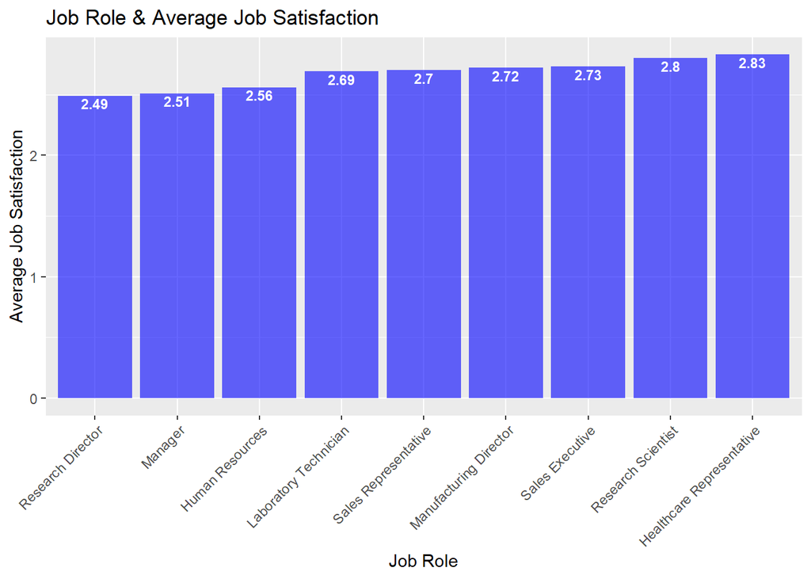

```r
#  Get average monthly salary for each job satisfaction categories
satis <- empl_data %>% group_by(JobRole) %>% summarize(mean_size = round(mean(JobSatisfaction), digits = 2))

# Plot data
p <- satis %>%
  ggplot(aes(x = reorder(JobRole, mean_size), y = mean_size)) +
  geom_bar(stat = "identity", fill = "blue", alpha = .6) +
  ggtitle("Job Role & Average Job Satisfaction") + xlab("Job Role") + ylab("Average Job Satisfaction")  +
  geom_text(aes(y = mean_size, label = mean_size), fontface = "bold", vjust = 1.2, color = "white", size = 3)

p + rotate_x_text(45)
```

- Average Job Involvement By Job Role - Sales Reps have the Lowest Average Job Involvement

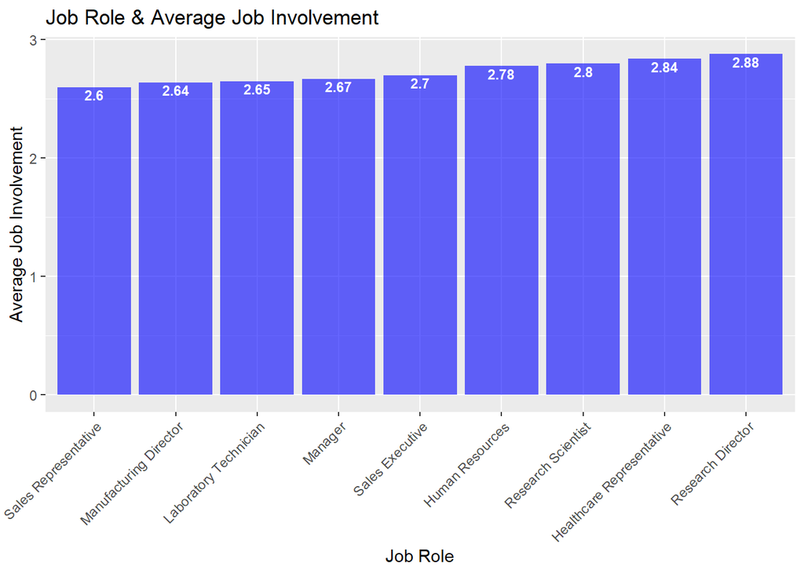

```r
#  Get average monthly salary for each job satisfaction categories
involve <- empl_data %>% group_by(JobRole) %>% summarize(mean_size = round(mean(JobInvolvement), digits = 2))

# Plot data
p <- involve %>%
  ggplot(aes(x = reorder(JobRole, mean_size), y = mean_size)) +
  geom_bar(stat = "identity", fill = "blue", alpha = .6) +
  ggtitle("Job Role & Average Job Involvement") + xlab("Job Role") + ylab("Average Job Involvement")  +
  geom_text(aes(y = mean_size, label = mean_size), fontface = "bold", vjust = 1.2, color = "white", size = 3)

p + rotate_x_text(45)
```

- Attrition By Overtime - Non-Salaried or Overtime Employees have Higher Attrition

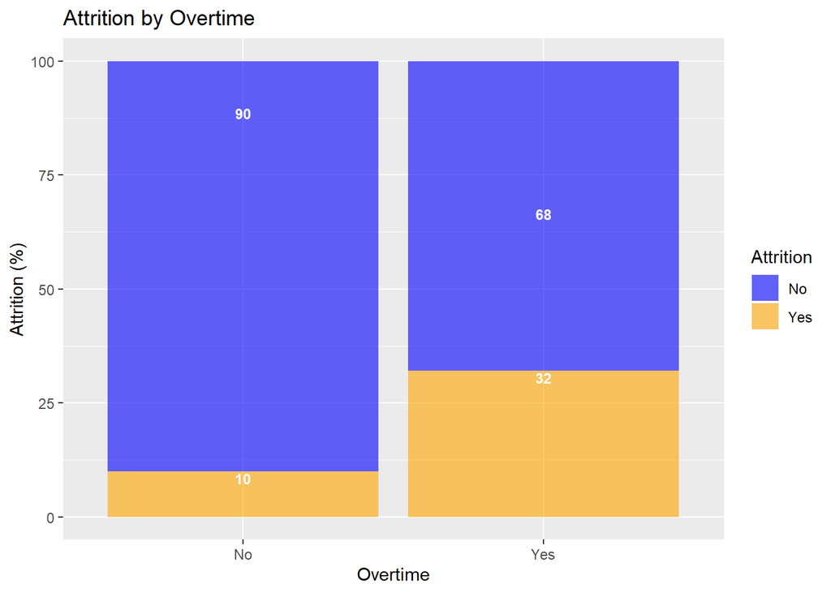

```r
#  Group jobs by job role and calculate percentage of attrition
overtime <- empl_data %>% group_by(OverTime, Attrition) %>% summarize(count=n()) %>% mutate(total_by_overtime = sum(count))
overtime$pct <- round(overtime$count/overtime$total_by_overtime, digits = 2)*100

# Plot attrition by job role

p <- ggplot(data=overtime, aes(x=OverTime, y=pct, fill=Attrition)) + geom_bar(stat="identity", alpha = .6) +
  ggtitle("Attrition by Overtime") + xlab("Overtime") + ylab("Attrition (%)") + scale_fill_manual(values = c("blue","orange")) +
  geom_text(aes(y = pct, label = pct), fontface = "bold", nudge_y = -1.5, color = "white", size = 3)

p
```

- Attrition By Marital Status - Singles have the Highest Attrition While Divorced Employees have the Lowest Attrition

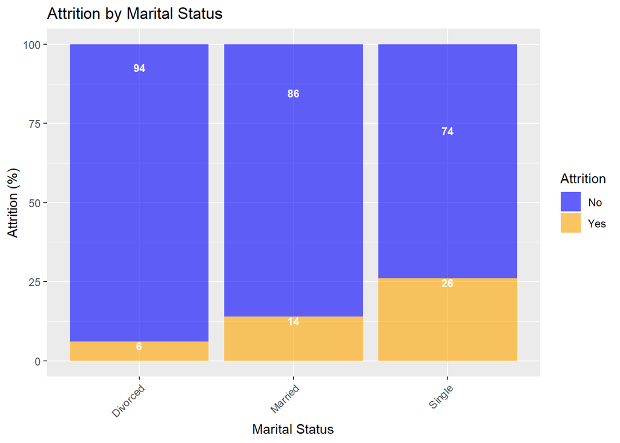

```r
#  Group jobs by job role and calculate percentage of attrition
married <- empl_data %>% group_by(MaritalStatus, Attrition) %>% summarize(count=n()) %>% mutate(total_by_marriage = sum(count))
married$pct <- round(married$count/married$total_by_marriage, digits = 2)*100

# Plot attrition by job role

p <- ggplot(data=married, aes(x=MaritalStatus, y=pct, fill=Attrition)) + geom_bar(stat="identity", alpha = .6) +
  ggtitle("Attrition by Marital Status") + xlab("Marital Status") + ylab("Attrition (%)") + scale_fill_manual(values = c("blue","orange"))  +
  geom_text(aes(y = pct, label = pct), fontface = "bold", vjust = 1, color = "white", size = 3)

p + rotate_x_text(45)
```

- Attrition By Job Involvement - The Higher the Job Involvement, the Lower the Attrition is

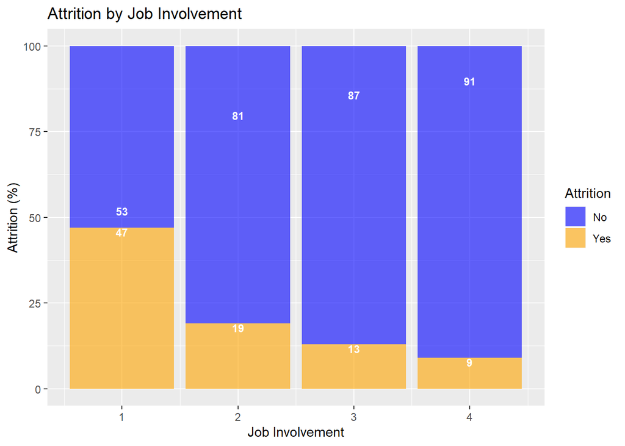

```r
#  Group jobs by job role and calculate percentage of attrition
job_involve <- empl_data %>% group_by(JobInvolvement, Attrition) %>% summarize(count=n()) %>% mutate(total_by_involvement = sum(count))
job_involve$pct <- round(job_involve$count/job_involve$total_by_involvement, digits = 2)*100

# Plot attrition by job role

p <- ggplot(data=job_involve, aes(x=JobInvolvement, y=pct, fill=Attrition)) + geom_bar(stat="identity", alpha = .6) +
  ggtitle("Attrition by Job Involvement") + xlab("Job Involvement") + ylab("Attrition (%)")  + scale_fill_manual(values = c("blue","orange")) +
  geom_text(aes(y = pct, label = pct), fontface = "bold", vjust = 1, color = "white", size = 3)

p
```

- Attrition By Role - Sales Reps have the Highest Attrition, While Research Directors, Manufacturing Directors, and Managers have the Lowest Attrition

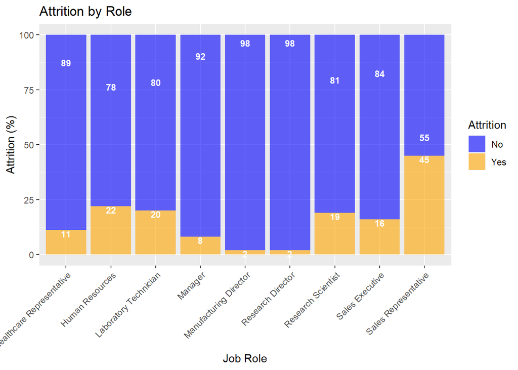

```r
#  Group jobs by job role and calculate percentage of attrition
job_role <- empl_data %>% group_by(JobRole, Attrition) %>% summarize(count=n()) %>% mutate(total_by_role = sum(count))
job_role$pct <- round(job_role$count/job_role$total_by_role, digits = 2)*100

# Plot attrition by job role

p <- ggplot(data=job_role, aes(x=JobRole, y=pct, fill=Attrition)) +
  geom_bar(stat="identity", alpha = .6) +
  ggtitle("Attrition by Role") + xlab("Job Role") + ylab("Attrition (%)") + scale_fill_manual(values = c("blue","orange")) +
geom_text(aes(y = pct, label = pct), fontface = "bold", vjust = 1, color = "white", size = 3)

p + rotate_x_text(45)
```

- Attrition By Salary - Higher Paying Jobs Have Lower Attrition

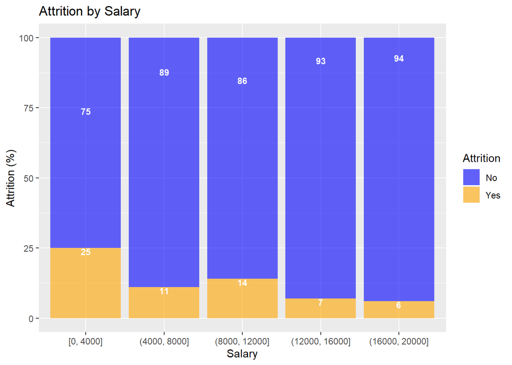

```r
income_attr <- empl_data
income_attr$bin <- bin_data(income_attr$MonthlyIncome, bins=c(0, 4000, 8000, 12000, 16000, 20000), boundaryType = "[lorc")

income_attr <- income_attr %>% group_by(bin, Attrition) %>% summarize(count=n()) %>% mutate(total_by_bin = sum(count))
income_attr$pct <- round(income_attr$count/income_attr$total_by_bin, digits = 2)*100

p <- ggplot(data=income_attr, aes(x=bin, y=pct, fill=Attrition)) + geom_bar(stat="identity", alpha = .6) +
  ggtitle("Attrition by Salary") + xlab("Salary") + ylab("Attrition (%)")  + scale_fill_manual(values = c("blue","orange")) +
  geom_text(aes(y = pct, label = pct), fontface = "bold", vjust = 1, color = "white", size = 3)

p
```

- Attrition By Job Satisfaction - Higher Job Satisfaction Does Lead to Lower Attrition Overall

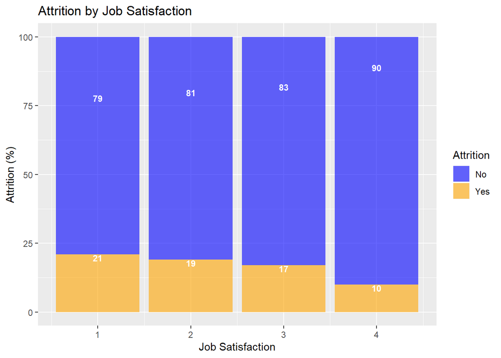

```r
#  Group jobs by job role and calculate percentage of attrition
job_satis <- empl_data %>% group_by(JobSatisfaction, Attrition) %>% summarize(count=n()) %>% mutate(total_by_satis = sum(count))
job_satis$pct <- round(job_satis$count/job_satis$total_by_satis, digits = 2)*100

# Plot attrition by job role

p <- ggplot(data=job_satis, aes(x=JobSatisfaction, y=pct, fill=Attrition)) + geom_bar(stat="identity", alpha = .6) +
  ggtitle("Attrition by Job Satisfaction") + xlab("Job Satisfaction") + ylab("Attrition (%)")  + scale_fill_manual(values = c("blue","orange")) +
  geom_text(aes(y = pct, label = pct), fontface = "bold", vjust = 1, color = "white", size = 3)

p
```

- Overtime and Job Involvement - Non-Salaried, Overtime Eligible Employees have Lower Job Involvement

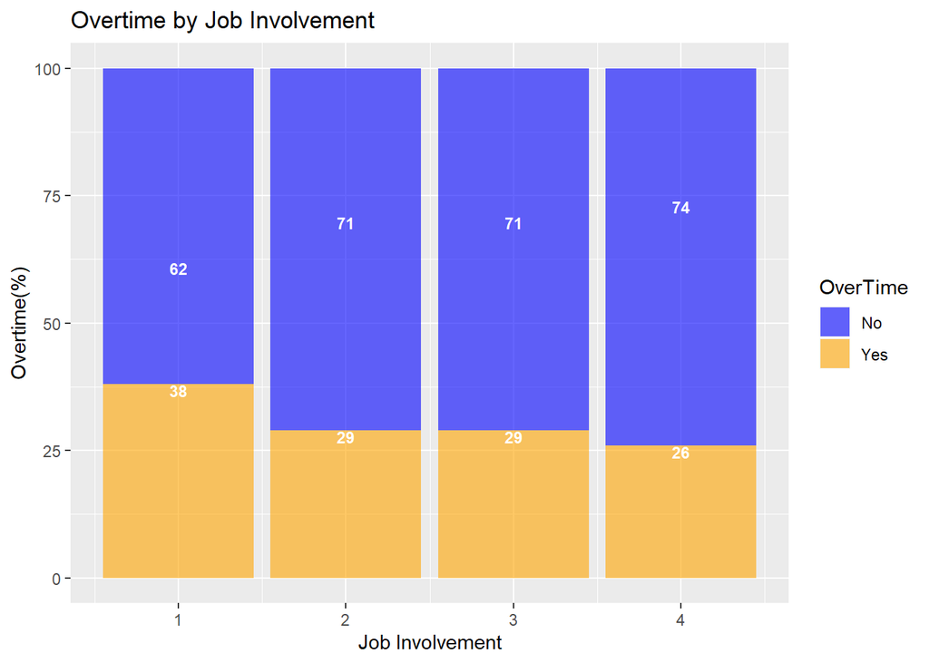

```r
#  Group jobs by job role and calculate percentage of attrition
job_over <- empl_data %>% group_by(JobInvolvement, OverTime) %>% summarize(count=n()) %>% mutate(total_by_involvement = sum(count))
job_over$pct <- round(job_over$count/job_over$total_by_involvement, digits = 2)*100

# Plot attrition by job role

p <- ggplot(data=job_over, aes(x=JobInvolvement, y=pct, fill=OverTime)) + geom_bar(stat="identity", alpha = .6) +
  ggtitle("Overtime by Job Involvement") + xlab("Job Involvement") + ylab("Overtime(%)")  + scale_fill_manual(values = c("blue","orange")) +
  geom_text(aes(y = pct, label = pct), fontface = "bold", vjust = 1, color = "white", size = 3)

p
```

- Marital Status and Job Involvement

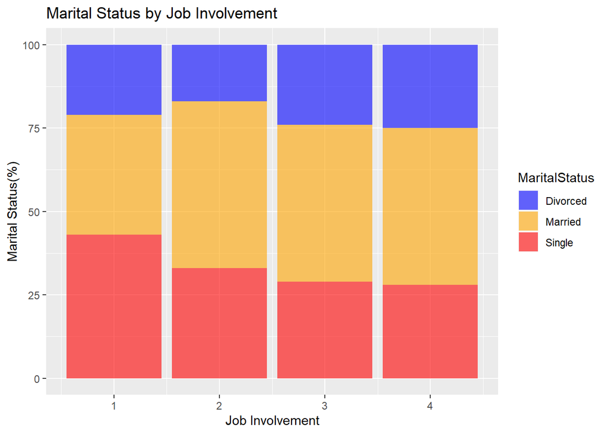

```r
#  Group jobs by job role and calculate percentage of attrition
marital_status <- empl_data %>% group_by(JobInvolvement, MaritalStatus) %>% summarize(count=n()) %>% mutate(total_by_involvement = sum(count))
marital_status$pct <- round(marital_status$count/marital_status$total_by_involvement, digits = 2)*100

# Plot attrition by job role

p <- ggplot(data=marital_status, aes(x=JobInvolvement, y=pct, fill=MaritalStatus)) + geom_bar(stat="identity", alpha = .6) +
  ggtitle("Marital Status by Job Involvement") + xlab("Job Involvement") + ylab("Marital Status(%)")  + scale_fill_manual(values = c("blue","orange", "red"))
p
```

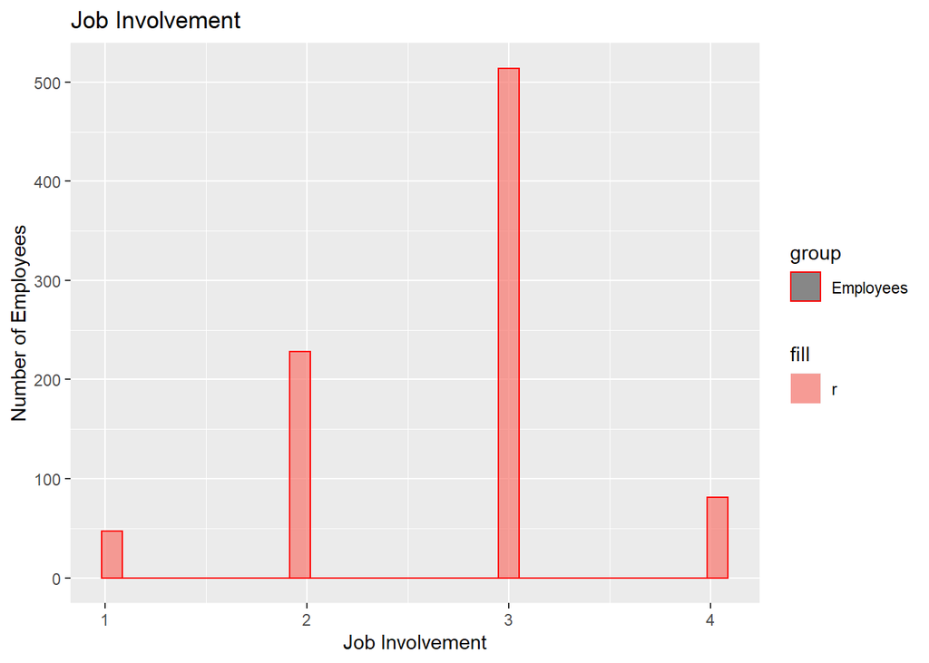

```r
p <- ggplot() +
  geom_histogram(aes(x=JobInvolvement, fill = "r", color="r"), alpha=.7, data=empl_data, stat = "bin") +
  ggtitle("Job Involvement") + xlab("Job Involvement") + ylab("Number of Employees") +
  scale_color_manual(name="group", values=c("r" = "red"), labels=c("r"="Employees"))

p
```

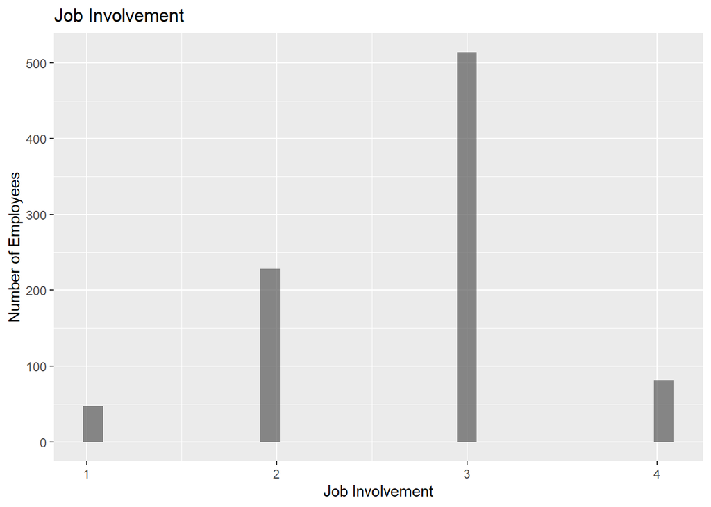

```r
p <- ggplot() +
  geom_histogram(aes(x=JobInvolvement), alpha=.7, data=empl_data, stat = "bin") +
  ggtitle("Job Involvement") + xlab("Job Involvement") + ylab("Number of Employees") +
  scale_color_manual(name="Employees", values=c("r" = "red"))

p
```

- Exploration - facet_wrap on all columns

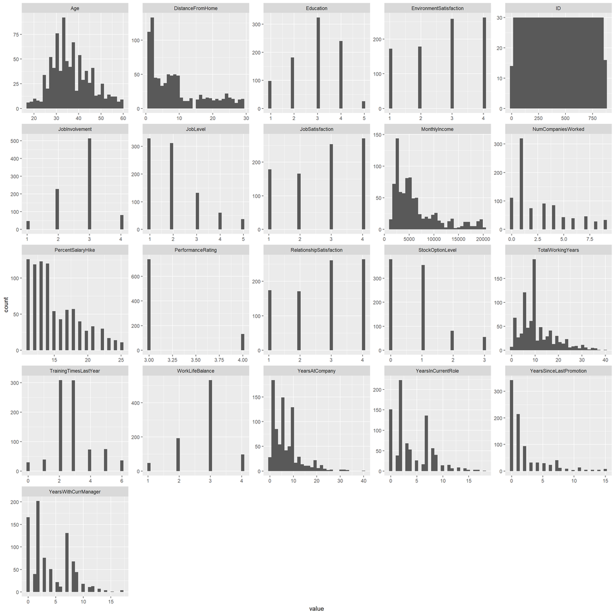

```r
# Get histograms of the data
empl_data %>% keep(is.numeric) %>% gather %>% ggplot(aes(x = value)) + facet_wrap(~key, scales = "free")+ geom_histogram()
```

- Correlation plot

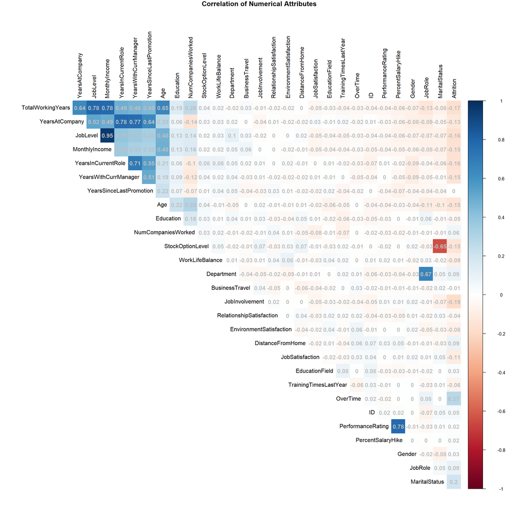

```r
empl_data_corr <- empl_data

# Make factors into integers
empl_data_corr[c("JobRole","BusinessTravel","Department","EducationField","Gender", "JobSatisfaction", "MaritalStatus", "OverTime")] <-  lapply(empl_data[c("JobRole","BusinessTravel","Department","EducationField","Gender", "JobSatisfaction", "MaritalStatus", "OverTime")], as.integer)

# Change Attrition to an integer
empl_data_corr$Attrition <- as.numeric(empl_data_corr$Attrition)

empl_data_corr %>%
  keep(is.numeric) %>%
  cor %>%
  corrplot("upper", diag = FALSE, order = "FPC", tl.pos = "td", tl.cex = 1, method = "color", tl.col = "black", addCoef.col = "grey", number.digits = 2, title="Correlation of Numerical Attributes", mar=c(0,0,1,0))
```

```r
# From this graph, not many of the attributes seem to be highly correlated with Attrition.  But these are the highest two attributes:  JobInvolvement, OverTime, and Marital Status.
```

- GGpairs with the some of the features

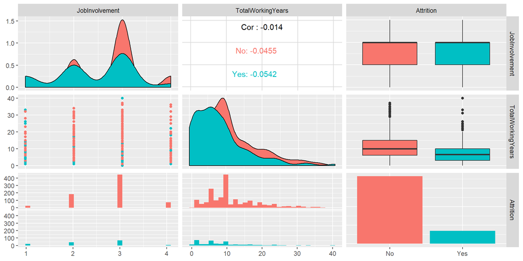

```r
empl_data %>%
select(JobInvolvement, TotalWorkingYears, Attrition) %>%
ggpairs(mapping = aes(color = Attrition))
```

```r
# New dataset
empl_knn <- empl_data

# Make factors into integers
empl_knn[c("JobRole","BusinessTravel","Department","EducationField","Gender", "JobSatisfaction", "MaritalStatus", "OverTime")] <- lapply(empl_knn[c("JobRole","BusinessTravel","Department","EducationField","Gender", "JobSatisfaction", "MaritalStatus", "OverTime")], as.integer)

# Split training data into train and test data

set.seed(sample(1:100, 1))
split_perc = .75
train_idx = sample(1:dim(empl_knn)[1],round(split_perc * dim(empl_knn)[1]))
train_idx
```

[output not shown]

[output cut: 22 more lines]

```r
train = empl_knn[train_idx,]
test = empl_knn[-train_idx,]

# Run the classification model on all the features
classif_knn <-  knn(train[, 3:29],test[, 3:29],train$Attrition, prob = TRUE, k = 5)
results <- confusionMatrix(table(classif_knn,test$Attrition))
results
```

```
## Confusion Matrix and Statistics
##
##
## classif_knn  No Yes
##         No  178  31
##         Yes   7   2
##
##                Accuracy : 0.8257
##                  95% CI : (0.7687, 0.8736)
##     No Information Rate : 0.8486
##     P-Value [Acc > NIR] : 0.8504625
##
##                   Kappa : 0.0325
##
##  Mcnemar's Test P-Value : 0.0001907
##
##             Sensitivity : 0.96216
##             Specificity : 0.06061
##          Pos Pred Value : 0.85167
##          Neg Pred Value : 0.22222
##              Prevalence : 0.84862
##          Detection Rate : 0.81651
##    Detection Prevalence : 0.95872
##       Balanced Accuracy : 0.51138
##
##        'Positive' Class : No
##
```

```r
# Create new dataframes for accuracy results
acc_df_knn <- data.frame(feature_names=character(0),acc=numeric(0), sens=numeric(0), spec=numeric(0))

# New test/train data
set.seed(sample(1:100, 1))
split_perc = .75
train_idx = sample(1:dim(empl_knn)[1],round(split_perc * dim(empl_knn)[1]))
train_idx
```

[output not shown]

[output cut: 22 more lines]

```r
train_knn= empl_knn[train_idx,]
test_knn = empl_knn[-train_idx,]

# Run KNN on all of the features
for (i in 3:dim(empl_knn)[2]){
  if (i > 2) {
    classif_knn = knn(data.frame(train_knn[, i]),data.frame(test_knn[, i]),train_knn$Attrition, prob = TRUE, k = 100)
    results <- confusionMatrix(table(classif_knn,test_knn$Attrition))
    temp3 <- data.frame(feature_names=colnames(empl_data[i]), acc=results[[3]][1], sens = results$byClass[1], spec = results$byClass[2])
    acc_df_knn <- rbind(acc_df_knn, temp3)
  }
}

unique(acc_df_knn$acc)
```

```
## [1] 0.8394495
```

```r
unique(acc_df_knn$sens)
```

```
## [1] 1
```

```r
unique(acc_df_knn$spec)
```

```
## [1] 0
```

- KNN Cross Validation (CV) for each feature

```r
# Create new dataframes for accuracy results
acc_df_knn_cv <- data.frame(feature_names=character(0),acc=numeric(0), sens=numeric(0), spec=numeric(0))

# Run KNN CV on all of the features
for (i in 3:dim(empl_knn)[2]){
  if (i > 2) {
    results_cv = confusionMatrix(table(knn.cv(empl_knn[,i], empl_knn$Attrition, k = 5), empl_knn$Attrition))
    temp4 <- data.frame(feature_names=colnames(empl_knn[i]), acc=results_cv[[3]][1], sens = results_cv$byClass[1], spec = results_cv$byClass[2])
    acc_df_knn_cv <- rbind(acc_df_knn_cv, temp4)
  }
}

unique(acc_df_knn_cv$acc)
```

```
## [1] 0.8379310 0.8390805 0.8264368 0.8183908 0.8425287
```

```r
unique(acc_df_knn_cv$sens)
```

```
## [1] 0.9863014 1.0000000 0.9849315 0.9630137 0.9972603
```

```r
unique(acc_df_knn_cv$spec)
```

```
## [1] 0.06428571 0.00000000 0.03571429
```

```r
# In this one TotalWorkingYears had the highest accuracy, but the specificity is still low
```

- Naive Bayes - Train Model

```r
# Create a new df
empl_data2 <- empl_data[c(1:29)]

# Split training data into train and test data
set.seed(sample(1:100, 1))
split_perc = .75
train_idx = sample(1:dim(empl_data2)[1],round(split_perc * dim(empl_data2)[1]))
train_idx
```

[output not shown]

[output cut: 22 more lines]

```r
train = empl_data2[train_idx,]
test = empl_data2[-train_idx,]

# Create new dataframes for accuracy results
acc_df_nb <- data.frame(feature_names=character(0),acc=numeric(0), sens=numeric(0), spec=numeric(0))

model = naiveBayes(train[,3:29], train$Attrition, laplace = 1)
results_nb = confusionMatrix(table(predict(model,test[,3:29]),test$Attrition))
results_nb
```

```
## Confusion Matrix and Statistics
##
##
##        No Yes
##   No  164  16
##   Yes  12  26
##
##                Accuracy : 0.8716
##                  95% CI : (0.8197, 0.9129)
##     No Information Rate : 0.8073
##     P-Value [Acc > NIR] : 0.007955
##
##                   Kappa : 0.5716
##
##  Mcnemar's Test P-Value : 0.570750
##
##             Sensitivity : 0.9318
##             Specificity : 0.6190
##          Pos Pred Value : 0.9111
##          Neg Pred Value : 0.6842
##              Prevalence : 0.8073
##          Detection Rate : 0.7523
##    Detection Prevalence : 0.8257
##       Balanced Accuracy : 0.7754
##
##        'Positive' Class : No
##
```

- Naive Bayes - Predict Attrition on new data

```r
empl_attr_prdt <-  read.csv("CaseStudy2CompSet_No_Attrition.csv")

# Add column for Attrition
empl_attr_prdt$Attrition <- NA

# Reorder columns
empl_attr_prdt <- empl_attr_prdt[c(1,36,2:35)]

# Drop Over18, StandardHours, EmployeeCount, ID, MonthlyRate
empl_attr_prdt <- empl_attr_prdt[ , -which(names(empl_attr_prdt) %in% c("EmployeeNumber", "Over18","StandardHours", "EmployeeCount", "MonthlyRate", "HourlyRate", "DailyRate"))]

# Compare datasets
summary(comparedf(empl_data2, empl_attr_prdt))
```

```
##
##
## Table: Summary of data.frames
##
## version   arg               ncol   nrow
## --------  ---------------  -----  -----
## x         empl_data2          29    870
## y         empl_attr_prdt      29    300
##
##
##
## Table: Summary of overall comparison
##
## statistic                                                      value
## ------------------------------------------------------------  ------
## Number of by-variables                                             0
## Number of non-by variables in common                              29
## Number of variables compared                                      28
## Number of variables in x but not y                                 0
## Number of variables in y but not x                                 0
## Number of variables compared with some values unequal             28
## Number of variables compared with all values equal                 0
## Number of observations in common                                 300
## Number of observations in x but not y                            570
## Number of observations in y but not x                              0
## Number of observations with some compared variables unequal      300
## Number of observations with all compared variables equal           0
## Number of values unequal                                        6129
##
##
##
## Table: Variables not shared
##
## |                        |
## |:-----------------------|
## |No variables not shared |
##
##
##
## Table: Other variables not compared
```

[output cut: 667 more lines]

[output not shown]

```r
# Add prediction to MonthlyIncome column
empl_attr_prdt$Attrition <- model %>% predict(empl_attr_prdt)

# Export all data
write.csv(empl_attr_prdt, "Case2PredictionsHermanAttrition-Full.csv", row.names=FALSE)

# Export ID and Attrition
export_attr <- empl_attr_prdt[c(1,2)]
write.csv(export_attr, "Case2PredictionsHermanAttrition.csv", row.names=FALSE)
```

- Run NB on each feature individually

```r
# Run NB on all of the features
for (i in 3:dim(empl_data)[2]){
  if (i > 2) {
    model = naiveBayes(train[,i], train$Attrition, laplace = 1)
    results_nb = confusionMatrix(table(predict(model,test[,i]),test$Attrition))
    temp5 <- data.frame(acc = c(results_nb$overall[1]), sens = c(results_nb$byClass[1]), spec = c(results_nb$byClass[2]))
    acc_df_nb <-  rbind(acc_df_nb, temp5)
  }
}
```

[output not shown]

[output cut: 24 more lines]

[output not shown]

```r
str(test)
```

```
## 'data.frame':    218 obs. of  29 variables:
##  $ ID                      : int  11 24 28 32 41 44 45 49 58 61 ...
##  $ Attrition               : Factor w/ 2 levels "No","Yes": 1 1 2 1 1 1 1 2 1 2 ...
##  $ Age                     : int  43 31 33 33 58 42 23 18 29 36 ...
##  $ BusinessTravel          : Factor w/ 3 levels "Non-Travel","Travel_Frequently",..: 3 2 3 3 1 3 3 2 3 3 ...
##  $ Department              : Factor w/ 3 levels "Human Resources",..: 2 3 3 2 3 2 2 3 2 3 ...
##  $ DistanceFromHome        : int  6 2 9 21 2 9 1 5 3 3 ...
##  $ Education               : int  3 4 4 3 3 2 2 3 1 1 ...
##  $ EducationField          : Factor w/ 6 levels "Human Resources",..: 4 5 3 4 4 5 2 3 4 2 ...
##  $ EnvironmentSatisfaction : int  1 4 1 2 2 4 4 2 2 3 ...
##  $ Gender                  : Factor w/ 2 levels "Female","Male": 1 2 1 2 2 2 2 2 2 2 ...
##  $ JobInvolvement          : int  2 3 3 4 3 2 3 3 3 2 ...
##  $ JobLevel                : int  5 2 2 1 4 5 1 1 1 3 ...
##  $ JobRole                 : Factor w/ 9 levels "Healthcare Representative",..: 4 8 8 3 4 4 7 9 3 8 ...
##  $ JobSatisfaction         : int  3 1 1 2 2 4 3 2 1 4 ...
##  $ MaritalStatus           : Factor w/ 3 levels "Divorced","Married",..: 2 3 3 2 1 3 2 3 3 2 ...
##  $ MonthlyIncome           : int  19392 5332 8224 2028 16291 19613 1223 1878 4723 10325 ...
##  $ NumCompaniesWorked      : int  7 7 0 1 4 8 1 1 1 1 ...
##  $ OverTime                : Factor w/ 2 levels "No","Yes": 1 1 2 1 1 1 1 2 2 2 ...
##  $ PercentSalaryHike       : int  13 13 17 18 22 22 22 14 18 11 ...
##  $ PerformanceRating       : int  3 3 3 3 4 4 4 3 3 3 ...
##  $ RelationshipSatisfaction: int  4 4 1 4 4 4 4 4 4 1 ...
##  $ StockOptionLevel        : int  0 0 0 3 1 0 1 0 0 1 ...
##  $ TotalWorkingYears       : int  21 10 6 14 37 24 1 0 10 16 ...
##  $ TrainingTimesLastYear   : int  2 3 3 6 0 2 2 3 3 6 ...
##  $ WorkLifeBalance         : int  3 3 3 3 2 3 3 3 3 3 ...
##  $ YearsAtCompany          : int  16 5 5 14 16 1 1 0 10 16 ...
##  $ YearsInCurrentRole      : int  12 2 2 11 9 0 0 0 9 7 ...
##  $ YearsSinceLastPromotion : int  6 0 0 2 14 0 0 0 1 3 ...
##  $ YearsWithCurrManager    : int  14 3 3 13 14 1 1 0 5 7 ...
```

```r
acc_df_nb
```

```
##                  acc sens spec
## Accuracy   0.8073394    1    0
## Accuracy1  0.8073394    1    0
## Accuracy2  0.8073394    1    0
## Accuracy3  0.8073394    1    0
## Accuracy4  0.8073394    1    0
## Accuracy5  0.8073394    1    0
## Accuracy6  0.8073394    1    0
## Accuracy7  0.8073394    1    0
## Accuracy8  0.8073394    1    0
## Accuracy9  0.8073394    1    0
## Accuracy10 0.8073394    1    0
## Accuracy11 0.8073394    1    0
## Accuracy12 0.8073394    1    0
## Accuracy13 0.8073394    1    0
## Accuracy14 0.8073394    1    0
## Accuracy15 0.8073394    1    0
## Accuracy16 0.8073394    1    0
## Accuracy17 0.8073394    1    0
## Accuracy18 0.8073394    1    0
## Accuracy19 0.8073394    1    0
## Accuracy20 0.8073394    1    0
## Accuracy21 0.8073394    1    0
## Accuracy22 0.8073394    1    0
## Accuracy23 0.8073394    1    0
## Accuracy24 0.8073394    1    0
## Accuracy25 0.8073394    1    0
## Accuracy26 0.8073394    1    0
```

```r
max(acc_df_nb$acc)
```

```
## [1] 0.8073394
```

```r
min(acc_df_nb$sens)
```

```
## [1] 1
```

```r
max(acc_df_nb$spec)
```

```
## [1] 0
```

```r
# Sort data
sorted_results_nb <- acc_df_nb[order(-acc_df_nb$acc),][1:20,]
sorted_results_nb
```

```
##                  acc sens spec
## Accuracy   0.8073394    1    0
## Accuracy1  0.8073394    1    0
## Accuracy2  0.8073394    1    0
## Accuracy3  0.8073394    1    0
## Accuracy4  0.8073394    1    0
## Accuracy5  0.8073394    1    0
## Accuracy6  0.8073394    1    0
## Accuracy7  0.8073394    1    0
## Accuracy8  0.8073394    1    0
## Accuracy9  0.8073394    1    0
## Accuracy10 0.8073394    1    0
## Accuracy11 0.8073394    1    0
## Accuracy12 0.8073394    1    0
## Accuracy13 0.8073394    1    0
## Accuracy14 0.8073394    1    0
## Accuracy15 0.8073394    1    0
## Accuracy16 0.8073394    1    0
## Accuracy17 0.8073394    1    0
## Accuracy18 0.8073394    1    0
## Accuracy19 0.8073394    1    0
```

```r
# All values are the same with this model with factors and integers
head(sorted_results_nb)
```

```
##                 acc sens spec
## Accuracy  0.8073394    1    0
## Accuracy1 0.8073394    1    0
## Accuracy2 0.8073394    1    0
## Accuracy3 0.8073394    1    0
## Accuracy4 0.8073394    1    0
## Accuracy5 0.8073394    1    0
```

- Linear Regression - Train Model

```r
# Dataset to train on
empl_data
```

[output not shown]

[output cut: 6082 more lines]

```r
# Create a training df with only numeric variables
train_df <- empl_data %>% keep(is.numeric)

# Split the data
set.seed(123)
tr_samples <- train_df$MonthlyIncome %>% createDataPartition(p = .95, list = FALSE)
tr  <- train_df[tr_samples, ]
td <- train_df[-tr_samples, ]

# Build the model, use monthly income
model <- lm(MonthlyIncome ~., data = tr)

# Summarize the model
summary(model)
```

```
##
## Call:
## lm(formula = MonthlyIncome ~ ., data = tr)
##
## Residuals:
##     Min      1Q  Median      3Q     Max
## -5824.1  -873.6     2.1   716.9  4171.5
##
## Coefficients:
##                           Estimate Std. Error t value Pr(>|t|)
## (Intercept)              -868.3344   651.3256  -1.333   0.1828
## ID                         -0.2332     0.1935  -1.205   0.2286
## Age                        -6.4148     7.4322  -0.863   0.3883
## DistanceFromHome          -16.4453     5.9808  -2.750   0.0061 **
## Education                   3.7085    48.6910   0.076   0.9393
## EnvironmentSatisfaction   -78.2601    43.7874  -1.787   0.0743 .
## JobInvolvement             94.8562    68.1177   1.393   0.1641
## JobLevel                 3696.3719    71.6876  51.562  < 2e-16 ***
## JobSatisfaction           -21.2093    43.6024  -0.486   0.6268
## NumCompaniesWorked         -6.7518    21.9322  -0.308   0.7583
## PercentSalaryHike          32.1682    20.7837   1.548   0.1221
## PerformanceRating        -261.4066   211.8967  -1.234   0.2177
## RelationshipSatisfaction    8.9455    43.9773   0.203   0.8389
## StockOptionLevel           16.4825    56.8062   0.290   0.7718
## TotalWorkingYears          80.7375    14.0595   5.743 1.32e-08 ***
## TrainingTimesLastYear      17.8655    37.9178   0.471   0.6377
## WorkLifeBalance           -42.0739    68.0399  -0.618   0.5365
## YearsAtCompany             -8.0288    18.3454  -0.438   0.6618
## YearsInCurrentRole         -5.1678    22.2007  -0.233   0.8160
## YearsSinceLastPromotion     5.1519    20.2467   0.254   0.7992
## YearsWithCurrManager      -55.0792    21.7669  -2.530   0.0116 *
## ---
## Signif. codes:  0 '***' 0.001 '**' 0.01 '*' 0.05 '.' 0.1 ' ' 1
##
## Residual standard error: 1380 on 809 degrees of freedom
## Multiple R-squared:  0.9102, Adjusted R-squared:  0.908
## F-statistic:   410 on 20 and 809 DF,  p-value: < 2.2e-16
```

```r
# Make predictions on the test dataset
preds <- model %>% predict(td)

# Evaluate performance of the model with RMSE
RMSE(preds, td$MonthlyIncome)
```

```
## [1] 1326.108
```

- Linear Regression - Predict Salary on new data

```r
# Import csv file without salary data
empl_salary_prdt <-  read.csv("CaseStudy2CompSet_No_Salary.csv")

# Change Attrition to an integer
empl_salary_prdt$Attrition <- as.numeric(empl_salary_prdt$Attrition)

# Drop Over18, StandardHours, EmployeeCount, ID, MonthlyRate
empl_salary_prdt <- empl_salary_prdt[ , -which(names(empl_salary_prdt) %in% c("EmployeeNumber", "Over18","StandardHours", "EmployeeCount", "MonthlyRate", "HourlyRate", "DailyRate"))]

# Fix ID name
colnames(empl_salary_prdt)[1] <- "ID"

# Add a blank column for monthly income
income_pred <- empl_salary_prdt %>% keep(is.numeric)
income_pred$MonthlyIncome <- NA

# Add prediction to MonthlyIncome column
income_pred$MonthlyIncome <- model %>% predict(income_pred)
grep("MonthlyIncome", colnames(income_pred))
```

```
## [1] 22
```

```r
View(income_pred)

# Export full dataset
write.csv(income_pred, "Case2PredictionsHermanSalary-Full.csv", row.names=FALSE)

# Export ID and MonthlyIncome
export_df <- income_pred[c(1,22)]
write.csv(export_df, "Case2PredictionsHermanSalary.csv", row.names=FALSE)
```